# Notebook

### Web Information Retrieval and Data Mining - Assignment 3

```
Student: JORIS, WILLEMS (0908753)
```

#### Answer 1.1, Baseline (4p)

- Dense network, at least 3 layers, shaped like a pyramid
  - Last layer: 10 nodes, sigmoid.
  - Loss: categorical cross-entropy. Metric: accuracy
- No preprocessing, regularization. Get at least 70% accuracy.
- Explain design decisions. Discuss performance.
  - Does it overfit (large/growing gap between loss and val_loss)?

```
ReLU was chosen over sigmoid for computational reasons and similar performance. Starting point was a deep network (10 layers) which certainly has enough capacity to (over)fit training data. We regularise by step-wise reducing layers/neurons until the model (almost) starts underfitting. Some optimise…

Max val score: 83.42%
```

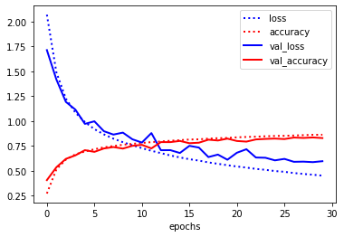

```
Model: "sequential_47"
_________________________________________________________________
Layer (type)                 Output Shape              Param #
=================================================================
reshape_47 (Reshape)         (None, 3072)              0
_________________________________________________________________
dense_218 (Dense)            (None, 512)               1573376
_________________________________________________________________
dense_219 (Dense)            (None, 256)               131328
_________________________________________________________________
dense_220 (Dense)            (None, 128)               32896
_________________________________________________________________
dense_221 (Dense)            (None, 10)                1290
=================================================================
Total params: 1,738,890
Trainable params: 1,738,890
Non-trainable params: 0
_________________________________________________________________
None
def build_model_1_1():

  model = models.Sequential()
  model.add(layers.Reshape((3072,), input_shape=(32,32,3)))

  model.add(layers.Dense(512, activation='relu'))

  model.add(layers.Dense(256, activation='relu'))

  model.add(layers.Dense(128, activation='relu'))

  model.add(layers.Dense(10, activation='softmax'))
  model.compile(optimizer='SGD',
                  loss='categorical_crossentropy',
                  metrics=['accuracy'])
  return model
```

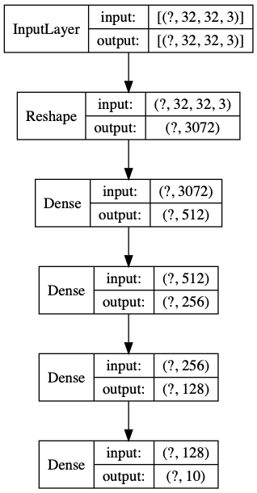

#### Answer 1.2, Preprocess (2p)

- Convert images to greyscale, other preprocessing optional.
  - Input shape should be (32,32,1)
- Explain design decisions. Is it better? Why (not)?
  - Color information is likely not so useful for classification. Greyscale makes the network smaller, less parameters to learn, less likely to overfit.

```
(length: 0)

Max val score: 83.84%
```

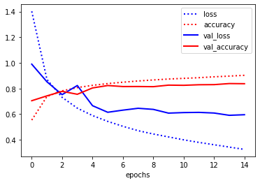

```
Model: "sequential_5"
_________________________________________________________________
Layer (type)                 Output Shape              Param #
=================================================================
reshape_5 (Reshape)          (None, 1024)              0
_________________________________________________________________
dense_17 (Dense)             (None, 512)               524800
_________________________________________________________________
dense_18 (Dense)             (None, 256)               131328
_________________________________________________________________
dense_19 (Dense)             (None, 128)               32896
_________________________________________________________________
dense_20 (Dense)             (None, 10)                1290
=================================================================
Total params: 690,314
Trainable params: 690,314
Non-trainable params: 0
_________________________________________________________________
None
def build_model_1_2():
  model = models.Sequential()
  model.add(layers.Reshape((32*32,), input_shape=(32**2,)))

  model.add(layers.Dense(512, activation='relu'))

  model.add(layers.Dense(256, activation='relu'))

  model.add(layers.Dense(128, activation='relu'))

  model.add(layers.Dense(10, activation='softmax'))
  model.compile(optimizer='SGD',
                  loss='categorical_crossentropy',
                  metrics=['accuracy'])
  return model
```

#### Answer 1.3, Tune (4p)

- Regularize the model. What works best?
  - Should consider batch normalization, dropout, l1/l2 regularization (or Nesterov)
- Tune other hyperparameters (e.g. learning rate, batch size,...) as you see fit.
  - At least consider tuning learning rate, ideally also momentum, decay, other optimizers
- Explain your findings and final design decisions. Discuss the results.
  - Should be better, at least it shouldn't overfit

```
(length: 0)

Max val score: 86.22%
```

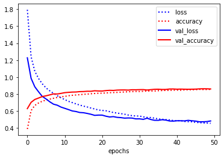

```
def build_model_1_3():
  model = models.Sequential()
  model.add(layers.Reshape((32*32,), input_shape=(32**2,)))
  model.add(layers.Dropout(0.15))

  model.add(layers.Dense(512, activation='relu'))
  model.add(layers.Dropout(0.12))

  model.add(layers.Dense(256, activation='relu'))
  model.add(layers.Dropout(0.10))

  model.add(layers.Dense(128, activation='relu'))
  model.add(layers.Dropout(0.05))

  model.add(layers.Dense(10, activation='softmax'))
  sgd = SGD(lr=0.015)
  model.compile(optimizer=sgd,
                  loss='categorical_crossentropy',
                  metrics=['accuracy'])
  return model
```

#### Answer 2.1, ConvNet (7p)

- Build a sequential ConvNet, get at least 90% accuracy.
  - Conv2D layers, input shape (32,32,1)
  - Consider using blocks of Conv2D layers with maxpooling in between
  - Use zero-padding in Conv2D layers because the images are small
  - At least one dense hidden layer and dense output layer (sigmoid)
  - Consider adding batch normalization, dropout
  - Consider small dropout rates in beginning, larger dropout rates later in network
  - Consider other optimizers and tuning learning rate, momentum,...
- Explain what you did and why (800 chars). Is it working well?
  - Should be quite elaborate and sensible

```
(length: 0)

Max val score: 95.22%
```

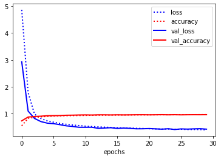

```
Model: "sequential_54"
_________________________________________________________________
Layer (type)                 Output Shape              Param #
=================================================================
conv2d_143 (Conv2D)          (None, 32, 32, 32)        320
_________________________________________________________________
batch_normalization_84 (Batc (None, 32, 32, 32)        128
_________________________________________________________________
conv2d_144 (Conv2D)          (None, 32, 32, 32)        9248
_________________________________________________________________
batch_normalization_85 (Batc (None, 32, 32, 32)        128
_________________________________________________________________
max_pooling2d_73 (MaxPooling (None, 16, 16, 32)        0
_________________________________________________________________
dropout_160 (Dropout)        (None, 16, 16, 32)        0
_________________________________________________________________
conv2d_145 (Conv2D)          (None, 16, 16, 64)        18496
_________________________________________________________________
batch_normalization_86 (Batc (None, 16, 16, 64)        256
_________________________________________________________________
conv2d_146 (Conv2D)          (None, 16, 16, 64)        36928
_________________________________________________________________
batch_normalization_87 (Batc (None, 16, 16, 64)        256
_________________________________________________________________
max_pooling2d_74 (MaxPooling (None, 8, 8, 64)          0
_________________________________________________________________
dropout_161 (Dropout)        (None, 8, 8, 64)          0
_________________________________________________________________
conv2d_147 (Conv2D)          (None, 8, 8, 128)         73856
_________________________________________________________________
batch_normalization_88 (Batc (None, 8, 8, 128)         512
_________________________________________________________________
conv2d_148 (Conv2D)          (None, 8, 8, 128)         147584
_________________________________________________________________
batch_normalization_89 (Batc (None, 8, 8, 128)         512
_________________________________________________________________
max_pooling2d_75 (MaxPooling (None, 4, 4, 128)         0
_________________________________________________________________
dropout_162 (Dropout)        (None, 4, 4, 128)         0
_________________________________________________________________
```

[output cut: 37 more lines]

```
  model.add(layers.Dropout(0.3))

  model.add(layers.Flatten())
  model.add(layers.Dense(128, activation='relu', kernel_regularizer=regularizers.l1(0.0007)))
  model.add(layers.BatchNormalization())
  model.add(layers.Dropout(0.2))

  model.add(layers.Dense(10, activation='softmax'))

  adam = Adam(learning_rate=0.00035)

  model.compile(optimizer=adam,
                loss='categorical_crossentropy',
                metrics=['accuracy'])
  return model
```

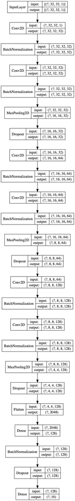

#### Answer 2.2, Data Augmentation (3p)

- Augment the preprocessed training data.
  - Use small variations (small shifts up-down, left-right) of flips becasue the images are small
  - Large shifts and rotations distort the image too much
- Explain what you did and why. Discuss the performance of the model.

```
(length: 0)

Max val score: 95.48%
```

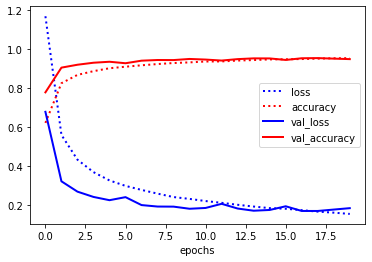

```
train_datagen = ImageDataGenerator(
    featurewise_center=False, #valt te proberen
    width_shift_range=0.1, #0.2
    height_shift_range=0.1, #0.2
    rotation_range=6,#[20]
    shear_range = 6, #20
    zoom_range = [0.95, 1.05]
)
```

#### Answer 3.1, Misclassifications (2p)

[output not shown]

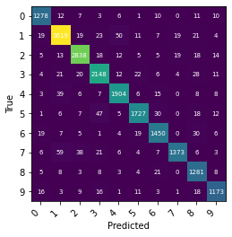

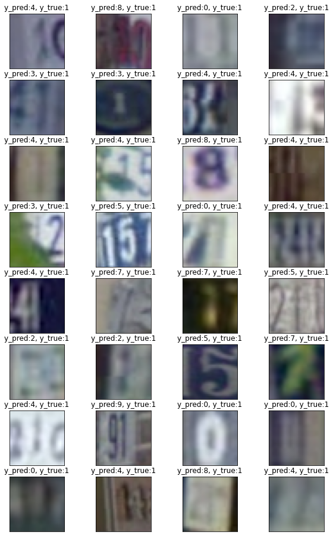

#### Answer 3.2, Activations (4p)

- Retrieve and visualize the activations for one example
- For every filter for different convolutional layers (at different depths in the network).
- Give an explanation. Is your model indeed learning something useful?
  - Should detect edges etc in first layers, higher-order object (e.g. interesting regions) in deeper layers.

```
(length: 0)
```

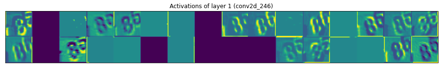

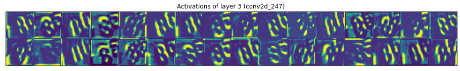

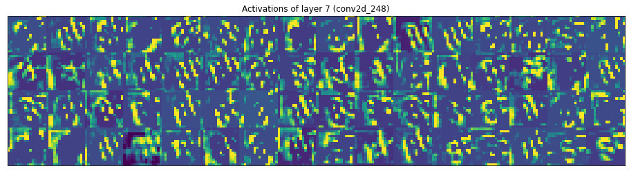

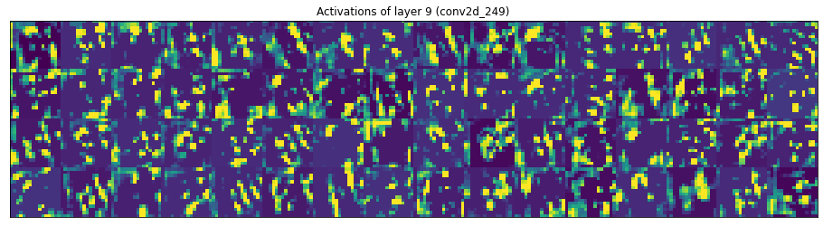

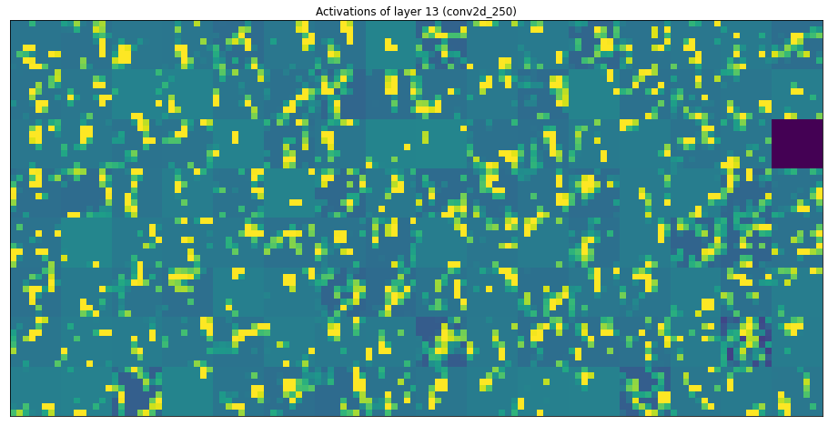

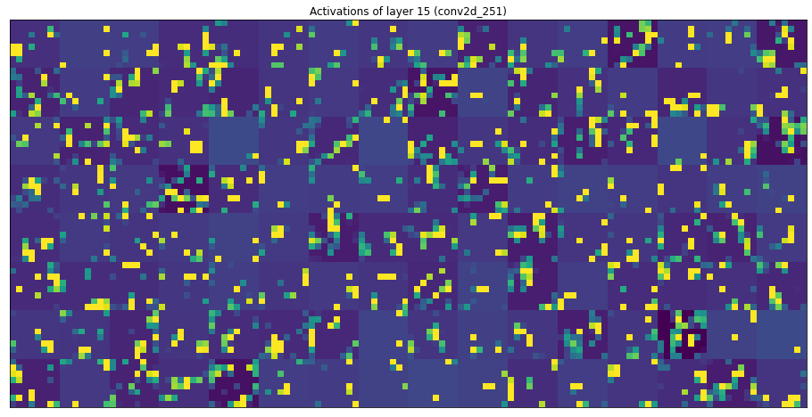

#### Answer 3.3, Class activation map (4p)

- Show a class activation map for your last convolutional layer
- Superimpose the activation map over the image, or plot side by side
  - Should make sense, detect interesting regions to classify the number

```
0 214
8 174
```

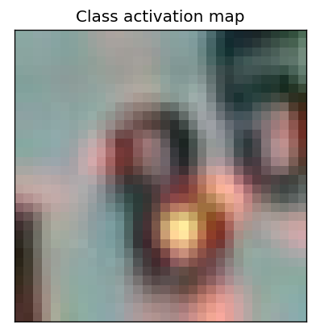

```
def plot_3_3():
    tf.compat.v1.disable_eager_execution()
    model = load_model_from_file(base_dir, "model_2_2")

    # retrieve and preprocess image
    x = rgb2gray(X_test[idx:idx+1]).reshape((1,32,32,1))

    # This is the "8" entry in the prediction vector
    classoutput = model.output[:,np.argmax(model.predict(x), axis=-1)[0]]

    # The is the output feature map of the 'conv2d_251' layer,
    # the last convolutional layer in network
    last_conv_layer = model.get_layer('conv2d_251')

    # This is the gradient of the "8" class with regard to
    # the output feature map of `conv2d_251`
    grads = K.gradients(classoutput, last_conv_layer.output)[0]

    # This is a vector of shape (128,), where each entry
    # is the mean intensity of the gradient over a specific feature map channel
    pooled_grads = K.mean(grads, axis=(0, 1, 2))

    # This function allows us to access the values of the quantities we just defined:
    # `pooled_grads` and the output feature map of `block5_conv3`,
    # given a sample image
    iterate = K.function([model.input], [pooled_grads, last_conv_layer.output[0]])

    # These are the values of these two quantities, as Numpy arrays,
    # given our sample image of two elephants
    pooled_grads_value, conv_layer_output_value = iterate([x])

    # We multiply each channel in the feature map array
    # by "how important this channel is" with regard to the elephant class
    for i in range(128):
        conv_layer_output_value[:, :, i] *= pooled_grads_value[i]

    # The channel-wise mean of the resulting feature map
    # is our heatmap of class activation
    heatmap = np.mean(conv_layer_output_value, axis=-1)
    heatmap = np.maximum(heatmap, 0)
```

[output cut: 15 more lines]

```
    # 0.5 here is a heatmap intensity factor
    superimposed_img = heatmapplot * 0.5 + img

    # Save the image to disk
    cv2.imwrite('class.jpg', superimposed_img)

    img = cv2.imread('class.jpg')
    RGB_im = cv2.cvtColor(img, cv2.COLOR_BGR2RGB)

    plt.rcParams['figure.dpi'] = 120
    plt.imshow(RGB_im)
    plt.title('Class activation map')
    plt.xticks([])
    plt.yticks([])
    plt.show()
```

#### Answer 4.1, Fast feature extraction (5p)

- Import the VGG16 model, pretrained on ImageNet
- Freeze convolutional base, adds a dense layer
- Consider unfreezing the last few convolutional layers and evaluate whether that works better
  - Check if they do. It is very likely to help.
- Discuss the observed performance
  - Should get around 80% accuracy

```
(length: 0)

Max val score: 94.41%
```

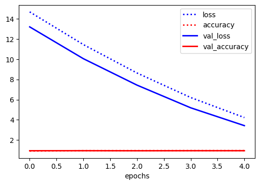

```
Model: "sequential_35"
_________________________________________________________________
Layer (type)                 Output Shape              Param #
=================================================================
vgg16 (Model)                (None, 1, 1, 512)         14714688
_________________________________________________________________
flatten_35 (Flatten)         (None, 512)               0
_________________________________________________________________
dense_66 (Dense)             (None, 128)               65664
_________________________________________________________________
batch_normalization_32 (Batc (None, 128)               512
_________________________________________________________________
dropout_32 (Dropout)         (None, 128)               0
_________________________________________________________________
dense_67 (Dense)             (None, 10)                1290
=================================================================
Total params: 14,782,154
Trainable params: 7,146,634
Non-trainable params: 7,635,520
_________________________________________________________________
None
def build_model_4_1():

    conv_base = VGG16(weights='imagenet',
                      include_top=False,
                      input_shape=(32, 32, 3))

    model = models.Sequential()
    model.add(conv_base)
    model.add(layers.Flatten())
    model.add(layers.Dense(128, activation='relu', kernel_regularizer=regularizers.l1(l=0.005)))
    model.add(layers.BatchNormalization())
    model.add(layers.Dropout(0.5))

    model.add(layers.Dense(10, activation='softmax'))

    conv_base.trainable = True

    set_trainable = False
    for layer in conv_base.layers:
        if layer.name == 'block5_conv1':
            set_trainable = True
        if set_trainable:
            layer.trainable = True
        else:
            layer.trainable = False

    model.compile(optimizer=Adam(lr=1e-4),
                  loss='categorical_crossentropy',
                  metrics=['accuracy'])
    return model
```

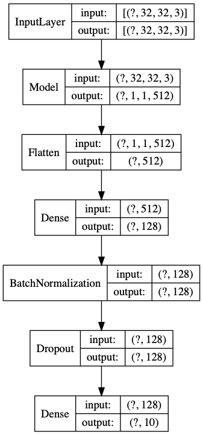

#### Answer 4.2, Embeddings (5p)

- Generate embeddings with the trained convolutional part of model_4_1 (without the dense layer)
- Embed the training and test data and store them to disk
- Build and evaluate a pipeline on the embedded data
  - Check if pipeline makes sense (e.g. use models that can handle many dimensions)
- Describe what you did and what you observed (max 800 chars).
  - Consider different models, preprocessing, tuning, etc.
  - Check performance (see original Submission.html) when in doubt. We did not run all the evaluations because it takes too long, and the output is ill-defined.

```
(length: 0)

Pipeline(steps=[('scaler', MinMaxScaler()),
                ('classifier', SVC(random_state=1))])
def store_embeddings():
    from tensorflow.keras import models

    source_model = load_model_from_file(base_dir,"model_4_1")

    model = models.Sequential()
    for layer in source_model.layers[:2]: # go through until last layer
        model.add(layer)
    model.summary()
    model.compile(optimizer='adam', loss='categorical_crossentropy')

    X_trainEmbed = model.predict(X_train, batch_size=1000, verbose=True).reshape((X_train.shape[0],512))
    X_valEmbed = model.predict(X_val, batch_size=1000, verbose=True).reshape((X_val.shape[0],512))
    X_testEmbed = model.predict(X_test, batch_size=1000, verbose=True).reshape((X_test.shape[0],512))
    store_embedding(X_trainEmbed, "train")
    store_embedding(X_valEmbed, "val")
    store_embedding(X_testEmbed, "test")

def evaluation_4_2(X_train, y_train, X_test, y_test):
    """ Runs 'evaluate_pipeline' with embedded versions of the input data
    and returns the accuracy.
    """
    pipe = generate_pipeline()
    xt = load_embedding("train")
    xv = load_embedding("test")
    return evaluate_pipeline(pipe, xt, y_train, xv, y_test)
```

```
Running time: 21.21 seconds
Last modified: May 26, 2020
scikit-learn version: 0.23.1
```